# Classification problem with Fake and Real news

## Hatem Hassan

```python
## This file has all imports and helper functions used throughout the notebook
%run python_helper.py
%matplotlib inline
```

# Clean & Save Data

Inspecting the data files, we noticed several issues for processing the traing dataset correctly. Using Regular Expression, we convert all commas between quotations to a pipe, so the CSV parsing works correctly with all values in their correct columns.

```python
input_str = open("fake_or_real_news_training.csv")

# Remove all new lines
noNewLines = re.sub("\n", "", input_str.read())

# re-add new line at end of each row
noNewLines = re.sub("X1,X2", "X1,X2\n", noNewLines)


noNewLines = re.sub(",FAKE[,]+", ",FAKE,,\n", noNewLines)
# noNewLines = re.sub(",FAKE,(?!,)",",FAKE,,\n",noNewLines)
# noNewLines = re.sub(",FAKE,,(?!,)",",FAKE,,\n",noNewLines)

noNewLines = re.sub(",REAL[,]+", ",REAL,,\n", noNewLines)
# noNewLines = re.sub(",REAL,(?!,)",",REAL,,\n",noNewLines)
# noNewLines = re.sub(",REAL,,(?!,)",",REAL,,\n",noNewLines)


# Replace any commas between two quotes with |
lines = noNewLines.split('\n')

def removeComma(g):
      t = g.groups()
      t = [t[0], t[1].replace(',', ' |'), t[2], t[3]]
      return "".join(t)

betweenQuotes = lambda line: re.sub(r'(.*,")(.*)(",)(.*)', lambda x: removeComma(x), line)

secondCol = lambda line: re.sub(r'^([0-9]+,)(.*,.*)(,\")(.*)$', lambda x: removeComma(x), line, 1)


lines = [betweenQuotes(l) for l in lines]
lines = [secondCol(l) for l in lines]

finalString = '\n'.join(lines)
```

### Save cleaned file

```python
file = open('fake_or_real_news_training_CLEANED.csv', 'w')
file.write(finalString)
file.close()
```

# Data Preparation

```python
train = pd.read_csv("fake_or_real_news_training_CLEANED.csv")
test = pd.read_csv("fake_or_real_news_test.csv")
```

```python
len(train)
```

```
3997
```

```python
len(test)
```

```
2321
```

```python
train.head()
```

|  | ID | title | text | label | X1 | X2 |
| --- | --- | --- | --- | --- | --- | --- |
| 0 | 8476 | You Can Smell Hillary’s Fear | Daniel Greenfield \| a Shillman Journalism Fell... | FAKE | NaN | NaN |
| 1 | 10294 | Watch The Exact Moment Paul Ryan Committed Pol... | Google Pinterest Digg Linkedin Reddit Stumbleu... | FAKE | NaN | NaN |
| 2 | 3608 | Kerry to go to Paris in gesture of sympathy | U.S. Secretary of State John F. Kerry said Mon... | REAL | NaN | NaN |
| 3 | 10142 | Bernie supporters on Twitter erupt in anger ag... | — Kaydee King (@KaydeeKing) November 9 \| 2016 ... | FAKE | NaN | NaN |
| 4 | 875 | The Battle of New York: Why This Primary Matte... | Cruz promised his supporters. ""We're beating... | REAL | NaN | NaN |

```python
train = train.drop(['X1', 'X2'], axis=1)
```

We study if the dataset is unbalanced. From the plot we see this is not the case, as there is a similar amount of Fake and Real news articles. No further actions have to be taken.

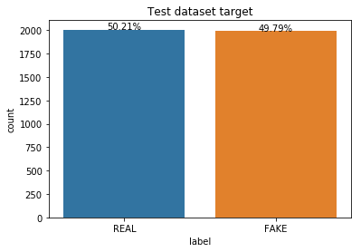

```python
from collections import Counter
ax = sns.countplot(train.label, order=[x for x, count in sorted(Counter(train.label).items(), key=lambda x: -x[1])])


for p in ax.patches:
    height = p.get_height()
    ax.text(p.get_x()+p.get_width()/2.,
            height + 3,
            '{:1.2f}%'.format(height/len(train)*100),
            ha="center")
ax.set_title("Test dataset target")
show()
```

```python
test.head()
```

|  | ID | title | text |
| --- | --- | --- | --- |
| 0 | 10498 | September New Homes Sales Rise——-Back To 1992 ... | September New Homes Sales Rise Back To 1992 Le... |
| 1 | 2439 | Why The Obamacare Doomsday Cult Can't Admit It... | But when Congress debated and passed the Patie... |
| 2 | 864 | Sanders, Cruz resist pressure after NY losses,... | The Bernie Sanders and Ted Cruz campaigns vowe... |
| 3 | 4128 | Surviving escaped prisoner likely fatigued and... | Police searching for the second of two escaped... |
| 4 | 662 | Clinton and Sanders neck and neck in Californi... | No matter who wins California's 475 delegates ... |

In order to not do double work by doing operations on our train and testset and to analyze general distributions of our data, we stack train and test in df.

```python
test['label'] = None  # empty label for test

df = pd.concat([train, test])
```

```python
len(df)
```

```
6318
```

```python
df.tail()
```

|  | ID | title | text | label |
| --- | --- | --- | --- | --- |
| 2316 | 4490 | State Department says it can't find emails fro... | The State Department told the Republican Natio... | None |
| 2317 | 8062 | The ‘P’ in PBS Should Stand for ‘Plutocratic’ ... | The ‘P’ in PBS Should Stand for ‘Plutocratic’ ... | None |
| 2318 | 8622 | Anti-Trump Protesters Are Tools of the Oligarc... | Anti-Trump Protesters Are Tools of the Oligar... | None |
| 2319 | 4021 | In Ethiopia, Obama seeks progress on peace, se... | ADDIS ABABA, Ethiopia —President Obama convene... | None |
| 2320 | 4330 | Jeb Bush Is Suddenly Attacking Trump. Here's W... | Jeb Bush Is Suddenly Attacking Trump. Here's W... | None |

# Data Preprocessing

In this part we will be cleaning the articles with the help of different NLP techniques, of which we will first explain the concept and its importance.

In order to take into account the title in our accuracy prediction, we created an extra column that combines text and title. We will not do seperate predictions on the title, since these might classify as e.g. Fake news, weather the actual text with more explanation tells a Real story.

```python
df['title_and_text'] = df['title'] +' '+ df['text']
df.tail()
```

|  | ID | title | text | label | title_and_text |
| --- | --- | --- | --- | --- | --- |
| 2316 | 4490 | State Department says it can't find emails fro... | The State Department told the Republican Natio... | None | State Department says it can't find emails fro... |
| 2317 | 8062 | The ‘P’ in PBS Should Stand for ‘Plutocratic’ ... | The ‘P’ in PBS Should Stand for ‘Plutocratic’ ... | None | The ‘P’ in PBS Should Stand for ‘Plutocratic’ ... |
| 2318 | 8622 | Anti-Trump Protesters Are Tools of the Oligarc... | Anti-Trump Protesters Are Tools of the Oligar... | None | Anti-Trump Protesters Are Tools of the Oligarc... |
| 2319 | 4021 | In Ethiopia, Obama seeks progress on peace, se... | ADDIS ABABA, Ethiopia —President Obama convene... | None | In Ethiopia, Obama seeks progress on peace, se... |
| 2320 | 4330 | Jeb Bush Is Suddenly Attacking Trump. Here's W... | Jeb Bush Is Suddenly Attacking Trump. Here's W... | None | Jeb Bush Is Suddenly Attacking Trump. Here's W... |

preprocess() can be found in python_helper.py Here you can read the explanations of the preprocess steps we took

1. lowercase the text

This preprocessing step is done so words van later be cross checked with the stopword and pos_tag dictionaries. For future analysis purposes, it could have been benefitial to analyze text with a lot of words in capital letters, by adding a flag variable.

1. remove the words counting just one letter

Idem step one.

1. remove the words that contain numbers

Idem step one.

1. tokenize the text and remove punctuation

We performed tokenization with the base python .string function, to split sentences into words (tokens).

1. remove all stop words

Relevant analysis of the text depends on the most recurring words. Stopwords including words as "the", "as" and "and" appear a lot in a text, but do not give relevant explanation. For this reason they are removed.

1. remove tokens that are empty

After tokenization, we have to make sure all tokens taken into account contribute to the label prediction.

1. pos tag the text

We use the pos_tag function included in the ntlk library. This classifies our tokenized words as a noun, verb, adjective or adverb and adds to the understaning of the articles.

1. lemmatize the text

In order to normalize the text, we apply lemmatization. In this way, words with the same root are processed equally e.g. when took or taken are read in the text, they are lemmatized to take, infinitive of the two verbs.

```python
df['preprocessed_text'] = df['title_and_text'].apply(lambda x: preprocess(x))
```

```python
## Save preprocessed df
df.to_csv("fake_or_real_news_train_PREPROCESSED.csv", index=False)
```

```python
df = pd.read_csv("fake_or_real_news_train_PREPROCESSED.csv")
df = df.astype(object).replace(np.nan, 'None')
```

```python
df.tail()
```

|  | ID | title | text | label | title_and_text | preprocessed_text |
| --- | --- | --- | --- | --- | --- | --- |
| 6313 | 4490 | State Department says it can't find emails fro... | The State Department told the Republican Natio... | None | State Department says it can't find emails fro... | state department say can't find emails clinton... |
| 6314 | 8062 | The ‘P’ in PBS Should Stand for ‘Plutocratic’ ... | The ‘P’ in PBS Should Stand for ‘Plutocratic’ ... | None | The ‘P’ in PBS Should Stand for ‘Plutocratic’ ... | ‘p’ pb stand ‘plutocratic’ ‘pentagon’ ‘p’ pb s... |
| 6315 | 8622 | Anti-Trump Protesters Are Tools of the Oligarc... | Anti-Trump Protesters Are Tools of the Oligar... | None | Anti-Trump Protesters Are Tools of the Oligarc... | anti-trump protester tool oligarchy informatio... |
| 6316 | 4021 | In Ethiopia, Obama seeks progress on peace, se... | ADDIS ABABA, Ethiopia —President Obama convene... | None | In Ethiopia, Obama seeks progress on peace, se... | ethiopia obama seek progress peace security ea... |
| 6317 | 4330 | Jeb Bush Is Suddenly Attacking Trump. Here's W... | Jeb Bush Is Suddenly Attacking Trump. Here's W... | None | Jeb Bush Is Suddenly Attacking Trump. Here's W... | jeb bush suddenly attack trump here's matter j... |

### Split Train and Test again after pre-processing is done

```python
encoder, train, test, train_cv, train_holdout, train_cv_label, train_holdout_label = split_train_holdout_test(encoder, df)
```

```
Train dataset (Full)
(3997, 7)
Train dataset cols
['ID', 'title', 'text', 'label', 'title_and_text', 'preprocessed_text', 'encoded_label']

Train CV dataset (subset)
(2677, 7)
Train Holdout dataset (subset)
(1320, 7)

Test dataset
(2321, 6)
Test dataset cols
['ID', 'title', 'text', 'label', 'title_and_text', 'preprocessed_text']
```

```python
encoder
```

```
LabelEncoder()
```

# Baseline Modelling

First, we create a dataframe called models to keep track of different models and their scores.

```python
models = pd.DataFrame(columns=['model_name', 'model_object', 'score'])
```

### Vectorizing dataset

For any text to be fed to a model, the text has to be transformed into numerical values. This process is called vectorizing and will be redone everytime a new feature is added.

```python
count_vect = CountVectorizer(analyzer = "word")

count_vectorizer = count_vect.fit(df.preprocessed_text)

train_cv_vector = count_vectorizer.transform(train_cv.preprocessed_text)
train_holdout_vector = count_vectorizer.transform(train_holdout.preprocessed_text)
test_vector = count_vectorizer.transform(test.preprocessed_text)
```

```python
count_vect.get_feature_names()[:10]
```

```
['___',
 '_blank',
 '_derosa',
 '_rt_op_edge',
 '_strauss',
 'aa',
 'aaa',
 'aaahhh',
 'aab',
 'aachen']
```

## Baseline Model 1: SVC

We create a baseline classification model with a support vector machine, a good model to handle complex classifications.

```
Baseline Model 1: SVC
GridSearchCV(cv=ShuffleSplit(n_splits=5, random_state=12345, test_size=0.2, train_size=None),
       error_score='raise-deprecating',
       estimator=SVC(C=1.0, cache_size=200, class_weight=None, coef0=0.0,
  decision_function_shape='ovr', degree=3, gamma='auto_deprecated',
  kernel='rbf', max_iter=-1, probability=False, random_state=None,
  shrinking=True, tol=0.001, verbose=False),
       fit_params=None, iid='warn', n_jobs=None,
       param_grid=[{'C': [1, 10, 50, 100], 'kernel': ['linear']}, {'C': [10, 100, 500, 1000], 'gamma': [0.0001], 'kernel': ['rbf']}],
       pre_dispatch='2*n_jobs', refit=True, return_train_score='warn',
       scoring=None, verbose=0)

CV-scores
Accuracy: 0.909 (+/-0.022) for params: {'C': 100, 'gamma': 0.0001, 'kernel': 'rbf'}
Accuracy: 0.902 (+/-0.030) for params: {'C': 500, 'gamma': 0.0001, 'kernel': 'rbf'}
Accuracy: 0.893 (+/-0.030) for params: {'C': 1000, 'gamma': 0.0001, 'kernel': 'rbf'}
Accuracy: 0.892 (+/-0.036) for params: {'C': 1, 'kernel': 'linear'}
Accuracy: 0.892 (+/-0.036) for params: {'C': 10, 'kernel': 'linear'}
Accuracy: 0.892 (+/-0.036) for params: {'C': 50, 'kernel': 'linear'}
Accuracy: 0.892 (+/-0.036) for params: {'C': 100, 'kernel': 'linear'}
Accuracy: 0.886 (+/-0.011) for params: {'C': 10, 'gamma': 0.0001, 'kernel': 'rbf'}


Best Estimator Params
SVC(C=100, cache_size=200, class_weight=None, coef0=0.0,
  decision_function_shape='ovr', degree=3, gamma=0.0001, kernel='rbf',
  max_iter=-1, probability=False, random_state=None, shrinking=True,
  tol=0.001, verbose=False)

Predictions:
['REAL' 'REAL' 'FAKE' ... 'REAL' 'FAKE' 'REAL']
```

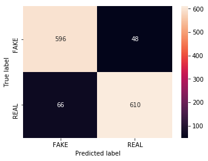

```
Accuracy:
0.9136363636363637
```

```python
SVC_classifier = runModel(encoder,
               train_cv_vector,
               train_cv_label,
               train_holdout_vector,
               train_holdout.label,
               "svc",
               "Baseline Model 1: SVC")
models.loc[len(models)] = SVC
```

## Baseline Model 2: Naïve Bayes

```
Baseline Model 2: Naiive Bayes
GridSearchCV(cv=ShuffleSplit(n_splits=5, random_state=12345, test_size=0.2, train_size=None),
       error_score='raise-deprecating',
       estimator=MultinomialNB(alpha=1.0, class_prior=None, fit_prior=True),
       fit_params=None, iid='warn', n_jobs=None, param_grid={},
       pre_dispatch='2*n_jobs', refit=True, return_train_score='warn',
       scoring=None, verbose=0)

CV-scores
Accuracy: 0.887 (+/-0.021) for params: {}


Best Estimator Params
MultinomialNB(alpha=1.0, class_prior=None, fit_prior=True)

Predictions:
['REAL' 'REAL' 'REAL' ... 'REAL' 'REAL' 'REAL']
```

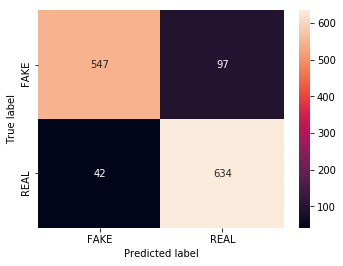

```
Accuracy:
0.8946969696969697
```

```python
NB = runModel(encoder,
              train_cv_vector,
              train_cv_label,
              train_holdout_vector,
              train_holdout.label,
              "nb",
              "Baseline Model 2: Naiive Bayes")
models.loc[len(models)] = NB
```

## Baseline Model 3: MaxEnt Classifier

```
Baseline Model 3: MaxEnt Classifier
GridSearchCV(cv=ShuffleSplit(n_splits=5, random_state=12345, test_size=0.2, train_size=None),
       error_score='raise-deprecating',
       estimator=LogisticRegression(C=1.0, class_weight=None, dual=False, fit_intercept=True,
          intercept_scaling=1, max_iter=100, multi_class='warn',
          n_jobs=None, penalty='l2', random_state=None, solver='warn',
          tol=0.0001, verbose=0, warm_start=False),
       fit_params=None, iid='warn', n_jobs=None,
       param_grid={'penalty': ['l1', 'l2'], 'C': [0.001, 0.01, 0.1, 1, 10, 100, 1000]},
       pre_dispatch='2*n_jobs', refit=True, return_train_score='warn',
       scoring=None, verbose=0)

CV-scores
Accuracy: 0.932 (+/-0.013) for params: {'C': 0.1, 'penalty': 'l2'}
Accuracy: 0.926 (+/-0.014) for params: {'C': 0.01, 'penalty': 'l2'}
Accuracy: 0.924 (+/-0.018) for params: {'C': 1, 'penalty': 'l2'}
Accuracy: 0.917 (+/-0.023) for params: {'C': 10, 'penalty': 'l2'}
Accuracy: 0.915 (+/-0.027) for params: {'C': 1, 'penalty': 'l1'}
Accuracy: 0.911 (+/-0.016) for params: {'C': 10, 'penalty': 'l1'}
Accuracy: 0.909 (+/-0.017) for params: {'C': 0.001, 'penalty': 'l2'}
Accuracy: 0.908 (+/-0.028) for params: {'C': 100, 'penalty': 'l1'}
Accuracy: 0.903 (+/-0.009) for params: {'C': 0.1, 'penalty': 'l1'}
Accuracy: 0.898 (+/-0.034) for params: {'C': 100, 'penalty': 'l2'}
Accuracy: 0.891 (+/-0.018) for params: {'C': 1000, 'penalty': 'l1'}
Accuracy: 0.882 (+/-0.023) for params: {'C': 1000, 'penalty': 'l2'}
Accuracy: 0.843 (+/-0.028) for params: {'C': 0.01, 'penalty': 'l1'}
Accuracy: 0.610 (+/-0.019) for params: {'C': 0.001, 'penalty': 'l1'}


Best Estimator Params
LogisticRegression(C=0.1, class_weight=None, dual=False, fit_intercept=True,
          intercept_scaling=1, max_iter=100, multi_class='warn',
          n_jobs=None, penalty='l2', random_state=None, solver='warn',
          tol=0.0001, verbose=0, warm_start=False)

Predictions:
['REAL' 'REAL' 'FAKE' ... 'REAL' 'FAKE' 'REAL']
```

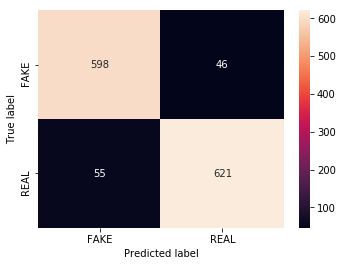

```
Accuracy:
0.9234848484848485
```

```python
maxEnt = runModel(encoder,
              train_cv_vector,
              train_cv_label,
              train_holdout_vector,
              train_holdout.label,
              "maxEnt",
              "Baseline Model 3: MaxEnt Classifier")
models.loc[len(models)] = maxEnt
```

# Baseline Models Summary

```python
models
```

|  | model_name | model_object | score |
| --- | --- | --- | --- |
| 0 | <class 'sklearn.svm.classes.SVC'> | <class 'sklearn.svm.classes.SVC'> | <class 'sklearn.svm.classes.SVC'> |
| 1 | Baseline Model 2: Naiive Bayes | GridSearchCV(cv=ShuffleSplit(n_splits=5, rando... | 0.894697 |
| 2 | Baseline Model 3: MaxEnt Classifier | GridSearchCV(cv=ShuffleSplit(n_splits=5, rando... | 0.923485 |

# Feature Engineeering

- Explicit POS tagging
- TF-IDF weighting
- Bigram Count Vectorizer

==> Select Final Model and predict on test

## 1. POS Tagging

Adding a prefix to each word with its type (Noun, Verb, Adjective,...). e.g: I went to school => PRP-I VBD-went TO-to NN-school

Also, after lemmatization it will be 'VB-go NN-school', which indicates the semantics and distingueshes the purpose of the sentence.

This will help the classifier differentiate between different types of sentences.

```python
df['pos_tagged_text'] = df['preprocessed_text'].apply(lambda x: pos_tag_words(x))
```

```python
df.head()
```

|  | ID | title | text | label | title_and_text | preprocessed_text | pos_tagged_text |
| --- | --- | --- | --- | --- | --- | --- | --- |
| 0 | 8476 | You Can Smell Hillary’s Fear | Daniel Greenfield \| a Shillman Journalism Fell... | FAKE | You Can Smell Hillary’s Fear Daniel Greenfield... | smell hillary’s fear daniel greenfield shillma... | NN-smell JJ-hillary NNP-’ NN-s NN-fear JJ-dani... |
| 1 | 10294 | Watch The Exact Moment Paul Ryan Committed Pol... | Google Pinterest Digg Linkedin Reddit Stumbleu... | FAKE | Watch The Exact Moment Paul Ryan Committed Pol... | watch exact moment paul ryan commit political ... | NN-watch JJ-exact NN-moment NN-paul JJ-ryan NN... |
| 2 | 3608 | Kerry to go to Paris in gesture of sympathy | U.S. Secretary of State John F. Kerry said Mon... | REAL | Kerry to go to Paris in gesture of sympathy U.... | kerry go paris gesture sympathy u.s secretary ... | NN-kerry VBP-go JJ-paris NN-gesture JJ-sympath... |
| 3 | 10142 | Bernie supporters on Twitter erupt in anger ag... | — Kaydee King (@KaydeeKing) November 9 \| 2016 ... | FAKE | Bernie supporters on Twitter erupt in anger ag... | bernie supporter twitter erupt anger dnc try w... | NN-bernie NN-supporter NN-twitter JJ-erupt NN-... |
| 4 | 875 | The Battle of New York: Why This Primary Matte... | Cruz promised his supporters. ""We're beating... | REAL | The Battle of New York: Why This Primary Matte... | battle new york primary matter primary day new... | NN-battle JJ-new NN-york JJ-primary NN-matter ... |

### Rerun Models on pos-tagged text (FE1)

```python
encoder, train, test, train_cv, train_holdout, train_cv_label, train_holdout_label = split_train_holdout_test(encoder, df, False)

count_vect = CountVectorizer(analyzer = "word")

count_vectorizer = count_vect.fit(df.preprocessed_text)

train_cv_vector = count_vectorizer.transform(train_cv.pos_tagged_text)
train_holdout_vector = count_vectorizer.transform(train_holdout.pos_tagged_text)
test_vector = count_vectorizer.transform(test.pos_tagged_text)
```

a. SVC with FE1

```
SVC on pos-tagged text
GridSearchCV(cv=ShuffleSplit(n_splits=5, random_state=12345, test_size=0.2, train_size=None),
       error_score='raise-deprecating',
       estimator=SVC(C=1.0, cache_size=200, class_weight=None, coef0=0.0,
  decision_function_shape='ovr', degree=3, gamma='auto_deprecated',
  kernel='rbf', max_iter=-1, probability=False, random_state=None,
  shrinking=True, tol=0.001, verbose=False),
       fit_params=None, iid='warn', n_jobs=None,
       param_grid=[{'C': [1, 10, 50, 100], 'kernel': ['linear']}, {'C': [10, 100, 500, 1000], 'gamma': [0.0001], 'kernel': ['rbf']}],
       pre_dispatch='2*n_jobs', refit=True, return_train_score='warn',
       scoring=None, verbose=0)

CV-scores
Accuracy: 0.921 (+/-0.026) for params: {'C': 100, 'gamma': 0.0001, 'kernel': 'rbf'}
Accuracy: 0.914 (+/-0.020) for params: {'C': 500, 'gamma': 0.0001, 'kernel': 'rbf'}
Accuracy: 0.912 (+/-0.028) for params: {'C': 1000, 'gamma': 0.0001, 'kernel': 'rbf'}
Accuracy: 0.912 (+/-0.022) for params: {'C': 10, 'gamma': 0.0001, 'kernel': 'rbf'}
Accuracy: 0.904 (+/-0.018) for params: {'C': 1, 'kernel': 'linear'}
Accuracy: 0.904 (+/-0.018) for params: {'C': 10, 'kernel': 'linear'}
Accuracy: 0.904 (+/-0.018) for params: {'C': 50, 'kernel': 'linear'}
Accuracy: 0.904 (+/-0.018) for params: {'C': 100, 'kernel': 'linear'}


Best Estimator Params
SVC(C=100, cache_size=200, class_weight=None, coef0=0.0,
  decision_function_shape='ovr', degree=3, gamma=0.0001, kernel='rbf',
  max_iter=-1, probability=False, random_state=None, shrinking=True,
  tol=0.001, verbose=False)

Predictions:
['REAL' 'REAL' 'FAKE' ... 'REAL' 'REAL' 'FAKE']
```

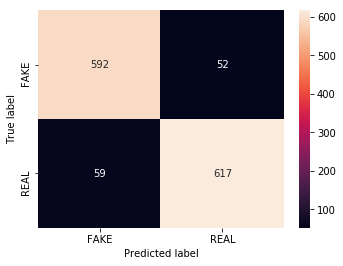

```
Accuracy:
0.9159090909090909
```

```python
SVC_pos_tag = runModel(encoder,
               train_cv_vector,
               train_cv_label,
               train_holdout_vector,
               train_holdout.label,
               "svc",
               "SVC on pos-tagged text")
models.loc[len(models)] = SVC_pos_tag
```

b. NB_pos_tag with FE1

```
Naiive Bayes on pos-tagged text
GridSearchCV(cv=ShuffleSplit(n_splits=5, random_state=12345, test_size=0.2, train_size=None),
       error_score='raise-deprecating',
       estimator=MultinomialNB(alpha=1.0, class_prior=None, fit_prior=True),
       fit_params=None, iid='warn', n_jobs=None, param_grid={},
       pre_dispatch='2*n_jobs', refit=True, return_train_score='warn',
       scoring=None, verbose=0)

CV-scores
Accuracy: 0.889 (+/-0.017) for params: {}


Best Estimator Params
MultinomialNB(alpha=1.0, class_prior=None, fit_prior=True)

Predictions:
['REAL' 'REAL' 'REAL' ... 'REAL' 'REAL' 'REAL']
```

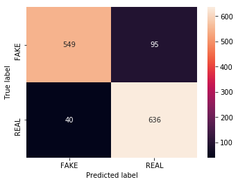

```
Accuracy:
0.8977272727272727
```

```python
NB_pos_tag = runModel(encoder,
              train_cv_vector,
              train_cv_label,
              train_holdout_vector,
              train_holdout.label,
              "nb",
              "Naiive Bayes on pos-tagged text")
models.loc[len(models)] = NB_pos_tag
```

c. maxEnt with FE1

```
MaxEnt Classifier on pos-tagged text
GridSearchCV(cv=ShuffleSplit(n_splits=5, random_state=12345, test_size=0.2, train_size=None),
       error_score='raise-deprecating',
       estimator=LogisticRegression(C=1.0, class_weight=None, dual=False, fit_intercept=True,
          intercept_scaling=1, max_iter=100, multi_class='warn',
          n_jobs=None, penalty='l2', random_state=None, solver='warn',
          tol=0.0001, verbose=0, warm_start=False),
       fit_params=None, iid='warn', n_jobs=None,
       param_grid={'penalty': ['l1', 'l2'], 'C': [0.001, 0.01, 0.1, 1, 10, 100, 1000]},
       pre_dispatch='2*n_jobs', refit=True, return_train_score='warn',
       scoring=None, verbose=0)

CV-scores
Accuracy: 0.930 (+/-0.026) for params: {'C': 0.1, 'penalty': 'l2'}
Accuracy: 0.929 (+/-0.030) for params: {'C': 1, 'penalty': 'l2'}
Accuracy: 0.927 (+/-0.018) for params: {'C': 0.01, 'penalty': 'l2'}
Accuracy: 0.924 (+/-0.028) for params: {'C': 1, 'penalty': 'l1'}
Accuracy: 0.922 (+/-0.024) for params: {'C': 10, 'penalty': 'l2'}
Accuracy: 0.920 (+/-0.022) for params: {'C': 100, 'penalty': 'l2'}
Accuracy: 0.919 (+/-0.021) for params: {'C': 10, 'penalty': 'l1'}
Accuracy: 0.919 (+/-0.020) for params: {'C': 1000, 'penalty': 'l2'}
Accuracy: 0.911 (+/-0.020) for params: {'C': 0.1, 'penalty': 'l1'}
Accuracy: 0.911 (+/-0.016) for params: {'C': 100, 'penalty': 'l1'}
Accuracy: 0.908 (+/-0.011) for params: {'C': 0.001, 'penalty': 'l2'}
Accuracy: 0.896 (+/-0.020) for params: {'C': 1000, 'penalty': 'l1'}
Accuracy: 0.848 (+/-0.026) for params: {'C': 0.01, 'penalty': 'l1'}
Accuracy: 0.662 (+/-0.021) for params: {'C': 0.001, 'penalty': 'l1'}


Best Estimator Params
LogisticRegression(C=0.1, class_weight=None, dual=False, fit_intercept=True,
          intercept_scaling=1, max_iter=100, multi_class='warn',
          n_jobs=None, penalty='l2', random_state=None, solver='warn',
          tol=0.0001, verbose=0, warm_start=False)

Predictions:
['REAL' 'REAL' 'FAKE' ... 'REAL' 'FAKE' 'REAL']
```

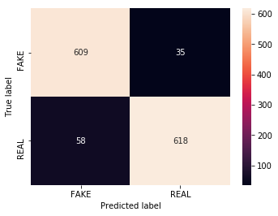

```
Accuracy:
0.9295454545454546
```

```python
maxEnt_pos_tag = runModel(encoder,
              train_cv_vector,
              train_cv_label,
              train_holdout_vector,
              train_holdout.label,
              "maxEnt",
              "MaxEnt Classifier on pos-tagged text")
models.loc[len(models)] = maxEnt_pos_tag
```

```python
models
```

|  | model_name | model_object | score |
| --- | --- | --- | --- |
| 0 | <class 'sklearn.svm.classes.SVC'> | <class 'sklearn.svm.classes.SVC'> | <class 'sklearn.svm.classes.SVC'> |
| 1 | Baseline Model 2: Naiive Bayes | GridSearchCV(cv=ShuffleSplit(n_splits=5, rando... | 0.894697 |
| 2 | Baseline Model 3: MaxEnt Classifier | GridSearchCV(cv=ShuffleSplit(n_splits=5, rando... | 0.923485 |
| 3 | SVC on pos-tagged text | GridSearchCV(cv=ShuffleSplit(n_splits=5, rando... | 0.915909 |
| 4 | Naiive Bayes on pos-tagged text | GridSearchCV(cv=ShuffleSplit(n_splits=5, rando... | 0.897727 |
| 5 | MaxEnt Classifier on pos-tagged text | GridSearchCV(cv=ShuffleSplit(n_splits=5, rando... | 0.929545 |

### There seems to be a slight increase in Accuracy after pos-tagging.

## 2. TF-IDF weighting

Try to add weight to each word using TF-IDF

[figure not shown]

We will also apply those on the cleaned text and the concatinated POS_tagged text.

```python
df["clean_and_pos_tagged_text"] = df['preprocessed_text'] + ' ' + df['pos_tagged_text']
```

```python
df.head(1)
```

|  | ID | title | text | label | title_and_text | preprocessed_text | pos_tagged_text | clean_and_pos_tagged_text |
| --- | --- | --- | --- | --- | --- | --- | --- | --- |
| 0 | 8476 | You Can Smell Hillary’s Fear | Daniel Greenfield \| a Shillman Journalism Fell... | FAKE | You Can Smell Hillary’s Fear Daniel Greenfield... | smell hillary’s fear daniel greenfield shillma... | NN-smell JJ-hillary NNP-’ NN-s NN-fear JJ-dani... | smell hillary’s fear daniel greenfield shillma... |

```python
encoder, train, test, train_cv, train_holdout, train_cv_label, train_holdout_label = split_train_holdout_test(encoder, df, False)

count_vect = CountVectorizer(analyzer = "word")

count_vectorizer = count_vect.fit(df.clean_and_pos_tagged_text)

train_cv_vector = count_vectorizer.transform(train_cv.clean_and_pos_tagged_text)
train_holdout_vector = count_vectorizer.transform(train_holdout.clean_and_pos_tagged_text)
test_vector = count_vectorizer.transform(test.clean_and_pos_tagged_text)


tf_idf = TfidfTransformer(norm="l2")
train_cv_tf_idf = tf_idf.fit_transform(train_cv_vector)
train_holdout_tf_idf = tf_idf.fit_transform(train_holdout_vector)
test_tf_idf = tf_idf.fit_transform(test_vector)
```

### Rerun Models on preprocessed + pos-tagged (FE1) + TF-IDF weighted text (FE2)

a. SVC with FE1 and FE2

```
SVC on preprocessed+pos-tagged TF-IDF weighted text
GridSearchCV(cv=ShuffleSplit(n_splits=5, random_state=12345, test_size=0.2, train_size=None),
       error_score='raise-deprecating',
       estimator=SVC(C=1.0, cache_size=200, class_weight=None, coef0=0.0,
  decision_function_shape='ovr', degree=3, gamma='auto_deprecated',
  kernel='rbf', max_iter=-1, probability=False, random_state=None,
  shrinking=True, tol=0.001, verbose=False),
       fit_params=None, iid='warn', n_jobs=None,
       param_grid=[{'C': [1, 10, 50, 100], 'kernel': ['linear']}, {'C': [10, 100, 500, 1000], 'gamma': [0.0001], 'kernel': ['rbf']}],
       pre_dispatch='2*n_jobs', refit=True, return_train_score='warn',
       scoring=None, verbose=0)

CV-scores
Accuracy: 0.937 (+/-0.026) for params: {'C': 50, 'kernel': 'linear'}
Accuracy: 0.937 (+/-0.026) for params: {'C': 100, 'kernel': 'linear'}
Accuracy: 0.937 (+/-0.024) for params: {'C': 10, 'kernel': 'linear'}
Accuracy: 0.935 (+/-0.020) for params: {'C': 1, 'kernel': 'linear'}
Accuracy: 0.895 (+/-0.008) for params: {'C': 1000, 'gamma': 0.0001, 'kernel': 'rbf'}
Accuracy: 0.859 (+/-0.016) for params: {'C': 500, 'gamma': 0.0001, 'kernel': 'rbf'}
Accuracy: 0.590 (+/-0.139) for params: {'C': 100, 'gamma': 0.0001, 'kernel': 'rbf'}
Accuracy: 0.481 (+/-0.027) for params: {'C': 10, 'gamma': 0.0001, 'kernel': 'rbf'}


Best Estimator Params
SVC(C=50, cache_size=200, class_weight=None, coef0=0.0,
  decision_function_shape='ovr', degree=3, gamma='auto_deprecated',
  kernel='linear', max_iter=-1, probability=False, random_state=None,
  shrinking=True, tol=0.001, verbose=False)

Predictions:
['REAL' 'REAL' 'FAKE' ... 'REAL' 'FAKE' 'REAL']
```

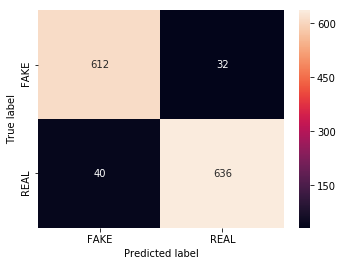

```
Accuracy:
0.9454545454545454
```

```python
SVC_tf_idf = runModel(encoder,
               train_cv_tf_idf,
               train_cv_label,
               train_holdout_tf_idf,
               train_holdout.label,
               "svc",
               "SVC on preprocessed+pos-tagged TF-IDF weighted text")
models.loc[len(models)] = SVC_tf_idf
```

b. NB with FE1 and FE2

```
Naiive Bayes on preprocessed+pos-tagged TF-IDF weighted text
GridSearchCV(cv=ShuffleSplit(n_splits=5, random_state=12345, test_size=0.2, train_size=None),
       error_score='raise-deprecating',
       estimator=MultinomialNB(alpha=1.0, class_prior=None, fit_prior=True),
       fit_params=None, iid='warn', n_jobs=None, param_grid={},
       pre_dispatch='2*n_jobs', refit=True, return_train_score='warn',
       scoring=None, verbose=0)

CV-scores
Accuracy: 0.781 (+/-0.039) for params: {}


Best Estimator Params
MultinomialNB(alpha=1.0, class_prior=None, fit_prior=True)

Predictions:
['REAL' 'REAL' 'REAL' ... 'REAL' 'REAL' 'REAL']
```

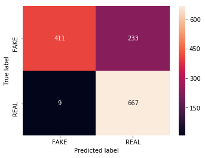

```
Accuracy:
0.8166666666666667
```

```python
NB_tf_idf = runModel(encoder,
               train_cv_tf_idf,
               train_cv_label,
               train_holdout_tf_idf,
               train_holdout.label,
              "nb",
              "Naiive Bayes on preprocessed+pos-tagged TF-IDF weighted text")
models.loc[len(models)] = NB_tf_idf
```

c. maxEnt with FE1 and FE2

```
MaxEnt on preprocessed+pos-tagged TF-IDF weighted text
GridSearchCV(cv=ShuffleSplit(n_splits=5, random_state=12345, test_size=0.2, train_size=None),
       error_score='raise-deprecating',
       estimator=LogisticRegression(C=1.0, class_weight=None, dual=False, fit_intercept=True,
          intercept_scaling=1, max_iter=100, multi_class='warn',
          n_jobs=None, penalty='l2', random_state=None, solver='warn',
          tol=0.0001, verbose=0, warm_start=False),
       fit_params=None, iid='warn', n_jobs=None,
       param_grid={'penalty': ['l1', 'l2'], 'C': [0.001, 0.01, 0.1, 1, 10, 100, 1000]},
       pre_dispatch='2*n_jobs', refit=True, return_train_score='warn',
       scoring=None, verbose=0)

CV-scores
Accuracy: 0.943 (+/-0.030) for params: {'C': 1000, 'penalty': 'l2'}
Accuracy: 0.940 (+/-0.023) for params: {'C': 1000, 'penalty': 'l1'}
Accuracy: 0.939 (+/-0.018) for params: {'C': 10, 'penalty': 'l1'}
Accuracy: 0.939 (+/-0.026) for params: {'C': 100, 'penalty': 'l2'}
Accuracy: 0.938 (+/-0.023) for params: {'C': 100, 'penalty': 'l1'}
Accuracy: 0.932 (+/-0.021) for params: {'C': 10, 'penalty': 'l2'}
Accuracy: 0.909 (+/-0.007) for params: {'C': 1, 'penalty': 'l2'}
Accuracy: 0.889 (+/-0.017) for params: {'C': 1, 'penalty': 'l1'}
Accuracy: 0.842 (+/-0.026) for params: {'C': 0.1, 'penalty': 'l2'}
Accuracy: 0.724 (+/-0.101) for params: {'C': 0.01, 'penalty': 'l2'}
Accuracy: 0.662 (+/-0.041) for params: {'C': 0.1, 'penalty': 'l1'}
Accuracy: 0.550 (+/-0.244) for params: {'C': 0.001, 'penalty': 'l2'}
Accuracy: 0.514 (+/-0.036) for params: {'C': 0.001, 'penalty': 'l1'}
Accuracy: 0.514 (+/-0.036) for params: {'C': 0.01, 'penalty': 'l1'}


Best Estimator Params
LogisticRegression(C=1000, class_weight=None, dual=False, fit_intercept=True,
          intercept_scaling=1, max_iter=100, multi_class='warn',
          n_jobs=None, penalty='l2', random_state=None, solver='warn',
          tol=0.0001, verbose=0, warm_start=False)

Predictions:
['REAL' 'REAL' 'FAKE' ... 'REAL' 'FAKE' 'REAL']
```

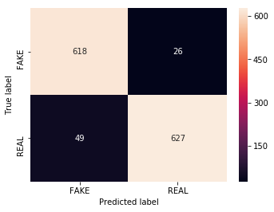

```
Accuracy:
0.9431818181818182
```

```python
maxEnt_tf_idf = runModel(encoder,
               train_cv_tf_idf,
               train_cv_label,
               train_holdout_tf_idf,
               train_holdout.label,
              "maxEnt",
              "MaxEnt on preprocessed+pos-tagged TF-IDF weighted text")
models.loc[len(models)] = maxEnt_tf_idf
```

```python
models
```

|  | model_name | model_object | score |
| --- | --- | --- | --- |
| 0 | <class 'sklearn.svm.classes.SVC'> | <class 'sklearn.svm.classes.SVC'> | <class 'sklearn.svm.classes.SVC'> |
| 1 | Baseline Model 2: Naiive Bayes | GridSearchCV(cv=ShuffleSplit(n_splits=5, rando... | 0.894697 |
| 2 | Baseline Model 3: MaxEnt Classifier | GridSearchCV(cv=ShuffleSplit(n_splits=5, rando... | 0.923485 |
| 3 | SVC on pos-tagged text | GridSearchCV(cv=ShuffleSplit(n_splits=5, rando... | 0.915909 |
| 4 | Naiive Bayes on pos-tagged text | GridSearchCV(cv=ShuffleSplit(n_splits=5, rando... | 0.897727 |
| 5 | MaxEnt Classifier on pos-tagged text | GridSearchCV(cv=ShuffleSplit(n_splits=5, rando... | 0.929545 |
| 6 | SVC on preprocessed+pos-tagged TF-IDF weighted... | GridSearchCV(cv=ShuffleSplit(n_splits=5, rando... | 0.945455 |
| 7 | Naiive Bayes on preprocessed+pos-tagged TF-IDF... | GridSearchCV(cv=ShuffleSplit(n_splits=5, rando... | 0.816667 |
| 8 | MaxEnt on preprocessed+pos-tagged TF-IDF weigh... | GridSearchCV(cv=ShuffleSplit(n_splits=5, rando... | 0.943182 |

### Using TF-IDF increased the score to ~94.5% with SVC and Max-Ent models. Naive-Bayes rather decreased the score. Therefore we drop it from the pipeline.

## 3. Use Bigram Vectorizer instead of regular vectorizer

```python
encoder, train, test, train_cv, train_holdout, train_cv_label, train_holdout_label = split_train_holdout_test(encoder, df, False)

trigram_vect = CountVectorizer(analyzer = "word", ngram_range=(1,2))

trigram_vect = count_vect.fit(df.clean_and_pos_tagged_text)

train_cv_vector = trigram_vect.transform(train_cv.clean_and_pos_tagged_text)
train_holdout_vector = trigram_vect.transform(train_holdout.clean_and_pos_tagged_text)
test_vector = trigram_vect.transform(test.clean_and_pos_tagged_text)
```

```python
tf_idf = TfidfTransformer(norm="l2")
train_cv_bigram_tf_idf = tf_idf.fit_transform(train_cv_vector)
train_holdout_bigram_tf_idf = tf_idf.fit_transform(train_holdout_vector)
test_bigram_tf_idf = tf_idf.fit_transform(test_vector)
```

a. SVC with FE1, FE2 and FE3

```
SVC on bigram vect.+ TF-IDF
GridSearchCV(cv=ShuffleSplit(n_splits=5, random_state=12345, test_size=0.2, train_size=None),
       error_score='raise-deprecating',
       estimator=SVC(C=1.0, cache_size=200, class_weight=None, coef0=0.0,
  decision_function_shape='ovr', degree=3, gamma='auto_deprecated',
  kernel='rbf', max_iter=-1, probability=False, random_state=None,
  shrinking=True, tol=0.001, verbose=False),
       fit_params=None, iid='warn', n_jobs=None,
       param_grid=[{'C': [1, 10, 50, 100], 'kernel': ['linear']}, {'C': [10, 100, 500, 1000], 'gamma': [0.0001], 'kernel': ['rbf']}],
       pre_dispatch='2*n_jobs', refit=True, return_train_score='warn',
       scoring=None, verbose=0)

CV-scores
Accuracy: 0.937 (+/-0.026) for params: {'C': 50, 'kernel': 'linear'}
Accuracy: 0.937 (+/-0.026) for params: {'C': 100, 'kernel': 'linear'}
Accuracy: 0.937 (+/-0.024) for params: {'C': 10, 'kernel': 'linear'}
Accuracy: 0.935 (+/-0.020) for params: {'C': 1, 'kernel': 'linear'}
Accuracy: 0.895 (+/-0.008) for params: {'C': 1000, 'gamma': 0.0001, 'kernel': 'rbf'}
Accuracy: 0.859 (+/-0.016) for params: {'C': 500, 'gamma': 0.0001, 'kernel': 'rbf'}
Accuracy: 0.590 (+/-0.139) for params: {'C': 100, 'gamma': 0.0001, 'kernel': 'rbf'}
Accuracy: 0.481 (+/-0.027) for params: {'C': 10, 'gamma': 0.0001, 'kernel': 'rbf'}


Best Estimator Params
SVC(C=50, cache_size=200, class_weight=None, coef0=0.0,
  decision_function_shape='ovr', degree=3, gamma='auto_deprecated',
  kernel='linear', max_iter=-1, probability=False, random_state=None,
  shrinking=True, tol=0.001, verbose=False)

Predictions:
['REAL' 'REAL' 'FAKE' ... 'REAL' 'FAKE' 'REAL']
```

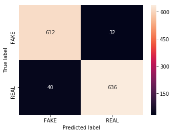

```
Accuracy:
0.9454545454545454
```

```python
SVC_trigram_tf_idf = runModel(encoder,
               train_cv_bigram_tf_idf,
               train_cv_label,
               train_holdout_bigram_tf_idf,
               train_holdout.label,
               "svc",
               "SVC on bigram vect.+ TF-IDF")
models.loc[len(models)] = SVC_trigram_tf_idf
```

b. maxEnt with FE1, FE2 and FE3

```python
encoder, train, test, train_cv, train_holdout, train_cv_label, train_holdout_label = split_train_holdout_test(encoder, df, False)

trigram_vect = CountVectorizer(analyzer = "word", ngram_range=(1,3))

trigram_vect = count_vect.fit(df.clean_and_pos_tagged_text)

train_cv_vector = trigram_vect.transform(train_cv.clean_and_pos_tagged_text)
train_holdout_vector = trigram_vect.transform(train_holdout.clean_and_pos_tagged_text)
```

```python
tf_idf = TfidfTransformer(norm="l2")
train_cv_trigram_tf_idf = tf_idf.fit_transform(train_cv_vector)
train_holdout_trigram_tf_idf = tf_idf.fit_transform(train_holdout_vector)
```

```
MaxEnt on trigram vect.+ TF-IDF
GridSearchCV(cv=ShuffleSplit(n_splits=5, random_state=12345, test_size=0.2, train_size=None),
       error_score='raise-deprecating',
       estimator=LogisticRegression(C=1.0, class_weight=None, dual=False, fit_intercept=True,
          intercept_scaling=1, max_iter=100, multi_class='warn',
          n_jobs=None, penalty='l2', random_state=None, solver='warn',
          tol=0.0001, verbose=0, warm_start=False),
       fit_params=None, iid='warn', n_jobs=None,
       param_grid={'penalty': ['l1', 'l2'], 'C': [0.001, 0.01, 0.1, 1, 10, 100, 1000]},
       pre_dispatch='2*n_jobs', refit=True, return_train_score='warn',
       scoring=None, verbose=0)

CV-scores
Accuracy: 0.943 (+/-0.029) for params: {'C': 1000, 'penalty': 'l2'}
Accuracy: 0.939 (+/-0.018) for params: {'C': 10, 'penalty': 'l1'}
Accuracy: 0.939 (+/-0.026) for params: {'C': 100, 'penalty': 'l2'}
Accuracy: 0.938 (+/-0.023) for params: {'C': 1000, 'penalty': 'l1'}
Accuracy: 0.938 (+/-0.023) for params: {'C': 100, 'penalty': 'l1'}
Accuracy: 0.932 (+/-0.021) for params: {'C': 10, 'penalty': 'l2'}
Accuracy: 0.909 (+/-0.007) for params: {'C': 1, 'penalty': 'l2'}
Accuracy: 0.889 (+/-0.017) for params: {'C': 1, 'penalty': 'l1'}
Accuracy: 0.842 (+/-0.026) for params: {'C': 0.1, 'penalty': 'l2'}
Accuracy: 0.724 (+/-0.101) for params: {'C': 0.01, 'penalty': 'l2'}
Accuracy: 0.662 (+/-0.041) for params: {'C': 0.1, 'penalty': 'l1'}
Accuracy: 0.550 (+/-0.244) for params: {'C': 0.001, 'penalty': 'l2'}
Accuracy: 0.514 (+/-0.036) for params: {'C': 0.001, 'penalty': 'l1'}
Accuracy: 0.514 (+/-0.036) for params: {'C': 0.01, 'penalty': 'l1'}


Best Estimator Params
LogisticRegression(C=1000, class_weight=None, dual=False, fit_intercept=True,
          intercept_scaling=1, max_iter=100, multi_class='warn',
          n_jobs=None, penalty='l2', random_state=None, solver='warn',
          tol=0.0001, verbose=0, warm_start=False)

Predictions:
['REAL' 'REAL' 'FAKE' ... 'REAL' 'FAKE' 'REAL']
```

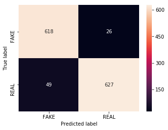

```
Accuracy:
0.9431818181818182
```

```python
maxEnt_tf_idf = runModel(encoder,
               train_cv_trigram_tf_idf,
               train_cv_label,
               train_holdout_trigram_tf_idf,
               train_holdout.label,
              "maxEnt",
              "MaxEnt on trigram vect.+ TF-IDF")
models.loc[len(models)] = maxEnt_tf_idf
```

```python
models
```

|  | model_name | model_object | score |
| --- | --- | --- | --- |
| 0 | <class 'sklearn.svm.classes.SVC'> | <class 'sklearn.svm.classes.SVC'> | <class 'sklearn.svm.classes.SVC'> |
| 1 | Baseline Model 2: Naiive Bayes | GridSearchCV(cv=ShuffleSplit(n_splits=5, rando... | 0.894697 |
| 2 | Baseline Model 3: MaxEnt Classifier | GridSearchCV(cv=ShuffleSplit(n_splits=5, rando... | 0.923485 |
| 3 | SVC on pos-tagged text | GridSearchCV(cv=ShuffleSplit(n_splits=5, rando... | 0.915909 |
| 4 | Naiive Bayes on pos-tagged text | GridSearchCV(cv=ShuffleSplit(n_splits=5, rando... | 0.897727 |
| 5 | MaxEnt Classifier on pos-tagged text | GridSearchCV(cv=ShuffleSplit(n_splits=5, rando... | 0.929545 |
| 6 | SVC on preprocessed+pos-tagged TF-IDF weighted... | GridSearchCV(cv=ShuffleSplit(n_splits=5, rando... | 0.945455 |
| 7 | Naiive Bayes on preprocessed+pos-tagged TF-IDF... | GridSearchCV(cv=ShuffleSplit(n_splits=5, rando... | 0.816667 |
| 8 | MaxEnt on preprocessed+pos-tagged TF-IDF weigh... | GridSearchCV(cv=ShuffleSplit(n_splits=5, rando... | 0.943182 |
| 9 | SVC on bigram vect.+ TF-IDF | GridSearchCV(cv=ShuffleSplit(n_splits=5, rando... | 0.945455 |
| 10 | MaxEnt on trigram vect.+ TF-IDF | GridSearchCV(cv=ShuffleSplit(n_splits=5, rando... | 0.943182 |

# Predicting on test dataset

## 1. Train on whole data and predict on test

### PREPROCESSED data

```python
test = pd.read_csv("fake_or_real_news_test.csv")
train = pd.read_csv("fake_or_real_news_training_CLEANED.csv")
```

```python
train['title_and_text'] = train['title'] +' '+ train['text']
train['preprocessed_text'] = train['title_and_text'].apply(lambda x: preprocess(x))
```

```python
test['title_and_text'] = test['title'] +' '+ test['text']
test['preprocessed_text'] = test['title_and_text'].apply(lambda x: preprocess(x))
```

```python
test.head()
```

```python
## Save preprocessed df
train.to_csv("fake_or_real_news_train_PREPROCESSED.csv", index=False)
```

```python
# Save preprocessed df
test.to_csv("fake_or_real_news_test_PREPROCESSED.csv", index=False)
```

```python
train = pd.read_csv("fake_or_real_news_train_PREPROCESSED.csv")
train = train.astype(object).replace(np.nan, 'None')

test = pd.read_csv("fake_or_real_news_test_PREPROCESSED.csv")
test = test.astype(object).replace(np.nan, 'None')
```

```python
test = test.astype(object).replace(np.nan, 'None')
```

```python
test.head()
```

|  | ID | title | text | title_and_text | preprocessed_text |
| --- | --- | --- | --- | --- | --- |
| 0 | 10498 | September New Homes Sales Rise——-Back To 1992 ... | September New Homes Sales Rise Back To 1992 Le... | September New Homes Sales Rise——-Back To 1992 ... | september new home sale rise——-back level sept... |
| 1 | 2439 | Why The Obamacare Doomsday Cult Can't Admit It... | But when Congress debated and passed the Patie... | Why The Obamacare Doomsday Cult Can't Admit It... | obamacare doomsday cult can't admit wrong cong... |
| 2 | 864 | Sanders, Cruz resist pressure after NY losses,... | The Bernie Sanders and Ted Cruz campaigns vowe... | Sanders, Cruz resist pressure after NY losses,... | sander cruz resist pressure ny loss vow fight ... |
| 3 | 4128 | Surviving escaped prisoner likely fatigued and... | Police searching for the second of two escaped... | Surviving escaped prisoner likely fatigued and... | survive escape prisoner likely fatigue prone m... |
| 4 | 662 | Clinton and Sanders neck and neck in Californi... | No matter who wins California's 475 delegates ... | Clinton and Sanders neck and neck in Californi... | clinton sander neck neck california primary ma... |

```python
train.head()
```

|  | ID | title | text | label | X1 | X2 | title_and_text | preprocessed_text |
| --- | --- | --- | --- | --- | --- | --- | --- | --- |
| 0 | 8476 | You Can Smell Hillary’s Fear | Daniel Greenfield \| a Shillman Journalism Fell... | FAKE | None | None | You Can Smell Hillary’s Fear Daniel Greenfield... | smell hillary’s fear daniel greenfield shillma... |
| 1 | 10294 | Watch The Exact Moment Paul Ryan Committed Pol... | Google Pinterest Digg Linkedin Reddit Stumbleu... | FAKE | None | None | Watch The Exact Moment Paul Ryan Committed Pol... | watch exact moment paul ryan commit political ... |
| 2 | 3608 | Kerry to go to Paris in gesture of sympathy | U.S. Secretary of State John F. Kerry said Mon... | REAL | None | None | Kerry to go to Paris in gesture of sympathy U.... | kerry go paris gesture sympathy u.s secretary ... |
| 3 | 10142 | Bernie supporters on Twitter erupt in anger ag... | — Kaydee King (@KaydeeKing) November 9 \| 2016 ... | FAKE | None | None | Bernie supporters on Twitter erupt in anger ag... | bernie supporter twitter erupt anger dnc try w... |
| 4 | 875 | The Battle of New York: Why This Primary Matte... | Cruz promised his supporters. ""We're beating... | REAL | None | None | The Battle of New York: Why This Primary Matte... | battle new york primary matter primary day new... |

### POS Tagging

```python
train['pos_tagged_text'] = train['preprocessed_text'].apply(lambda x: pos_tag_words(x))
test['pos_tagged_text'] = test['preprocessed_text'].apply(lambda x: pos_tag_words(x))
```

### merge clean and pos tagged

```python
train["clean_and_pos_tagged_text"] = train['preprocessed_text'] + ' ' + train['pos_tagged_text']
test["clean_and_pos_tagged_text"] = test['preprocessed_text'] + ' ' + train['pos_tagged_text']
```

```python
train.head(1)
```

|  | ID | title | text | label | X1 | X2 | title_and_text | preprocessed_text | pos_tagged_text | clean_and_pos_tagged_text |
| --- | --- | --- | --- | --- | --- | --- | --- | --- | --- | --- |
| 0 | 8476 | You Can Smell Hillary’s Fear | Daniel Greenfield \| a Shillman Journalism Fell... | FAKE | None | None | You Can Smell Hillary’s Fear Daniel Greenfield... | smell hillary’s fear daniel greenfield shillma... | NN-smell JJ-hillary NNP-’ NN-s NN-fear JJ-dani... | smell hillary’s fear daniel greenfield shillma... |

```python
test.head(1)
```

|  | ID | title | text | title_and_text | preprocessed_text | pos_tagged_text | clean_and_pos_tagged_text |
| --- | --- | --- | --- | --- | --- | --- | --- |
| 0 | 10498 | September New Homes Sales Rise——-Back To 1992 ... | September New Homes Sales Rise Back To 1992 Le... | September New Homes Sales Rise——-Back To 1992 ... | september new home sale rise——-back level sept... | VB-september JJ-new NN-home NN-sale JJ-rise——-... | september new home sale rise——-back level sept... |

## Modelling using MaxEnt on trigram vect.+ TF-IDF Grid Search Best params

### Trigram + Tfdif + classifier pipeline

```python
from sklearn.pipeline import Pipeline
trigram_vectorizer = CountVectorizer(analyzer = "word", ngram_range=(1,3))
tf_idf = TfidfTransformer(norm="l2")
classifier = LogisticRegression(C=1000, class_weight=None, dual=False, fit_intercept=True,
          intercept_scaling=1, max_iter=100, multi_class='warn',
          n_jobs=None, penalty='l2', random_state=None, solver='warn',
          tol=0.0001, verbose=0, warm_start=False)

pipeline = Pipeline([
     ('trigram_vectorizer', trigram_vectorizer),
     ('tfidf', tf_idf),
     ('clf', classifier),
 ])
```

```python
pipeline.fit(train.clean_and_pos_tagged_text, encoder.fit_transform(train.label.values))
```

```
Pipeline(memory=None,
     steps=[('trigram_vectorizer', CountVectorizer(analyzer='word', binary=False, decode_error='strict',
        dtype=<class 'numpy.int64'>, encoding='utf-8', input='content',
        lowercase=True, max_df=1.0, max_features=None, min_df=1,
        ngram_range=(1, 3), preprocessor=None, stop_words=None,...penalty='l2', random_state=None, solver='warn',
          tol=0.0001, verbose=0, warm_start=False))])
```

```python
import pickle
pickle.dump( pipeline, open( "pipeline.pkl", "wb" ) )
```

## 2. Predicting on test

```python
print(colored("Predicting on test", 'blue'))
test_predictions = test_predictions = pipeline.predict(test.clean_and_pos_tagged_text)
```

```
Predicting on test
```

```python
test_predictions
```

```
array([0, 0, 1, ..., 1, 1, 1])
```

```python
test_predictions_decoded = encoder.inverse_transform( test_predictions )
```

```python
predictions = test
predictions["label"] = test_predictions_decoded
```

```python
predictions.shape
```

```
(2321, 8)
```

```python
predictions.head()
```

|  | ID | title | text | title_and_text | preprocessed_text | pos_tagged_text | clean_and_pos_tagged_text | label |
| --- | --- | --- | --- | --- | --- | --- | --- | --- |
| 0 | 10498 | September New Homes Sales Rise——-Back To 1992 ... | September New Homes Sales Rise Back To 1992 Le... | September New Homes Sales Rise——-Back To 1992 ... | september new home sale rise——-back level sept... | VB-september JJ-new NN-home NN-sale JJ-rise——-... | september new home sale rise——-back level sept... | FAKE |
| 1 | 2439 | Why The Obamacare Doomsday Cult Can't Admit It... | But when Congress debated and passed the Patie... | Why The Obamacare Doomsday Cult Can't Admit It... | obamacare doomsday cult can't admit wrong cong... | NN-obamacare NN-doomsday NN-cult MD-ca RB-n't ... | obamacare doomsday cult can't admit wrong cong... | FAKE |
| 2 | 864 | Sanders, Cruz resist pressure after NY losses,... | The Bernie Sanders and Ted Cruz campaigns vowe... | Sanders, Cruz resist pressure after NY losses,... | sander cruz resist pressure ny loss vow fight ... | NN-sander NNS-cruz VBP-resist NN-pressure JJ-n... | sander cruz resist pressure ny loss vow fight ... | REAL |
| 3 | 4128 | Surviving escaped prisoner likely fatigued and... | Police searching for the second of two escaped... | Surviving escaped prisoner likely fatigued and... | survive escape prisoner likely fatigue prone m... | JJ-survive NN-escape NN-prisoner JJ-likely NN-... | survive escape prisoner likely fatigue prone m... | REAL |
| 4 | 662 | Clinton and Sanders neck and neck in Californi... | No matter who wins California's 475 delegates ... | Clinton and Sanders neck and neck in Californi... | clinton sander neck neck california primary ma... | NN-clinton NN-sander NN-neck NN-neck NN-califo... | clinton sander neck neck california primary ma... | REAL |

```python
predictions.label.describe()
```

```
count     2321
unique       2
top       REAL
freq      1320
Name: label, dtype: object
```

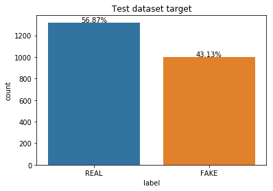

```python
import collections
ax = sns.countplot(predictions.label,
                order=[x for x, count in sorted(collections.Counter(predictions.label).items(),
                key=lambda x: -x[1])])


for p in ax.patches:
    height = p.get_height()
    ax.text(p.get_x()+p.get_width()/2.,
            height + 3,
            '{:1.2f}%'.format(height/len(predictions)*100),
            ha="center")
ax.set_title("Test dataset target")
show()
```

```python
predictions.drop(columns=["title","text","title_and_text","preprocessed_text","pos_tagged_text","clean_and_pos_tagged_text"]).head()
```

|  | ID | label |
| --- | --- | --- |
| 0 | 10498 | FAKE |
| 1 | 2439 | FAKE |
| 2 | 864 | REAL |
| 3 | 4128 | REAL |
| 4 | 662 | REAL |

```python
predictions.to_csv("TEST_PREDICTIONS.csv", index=False)
```